# Dimensionality Reduction with PCA and Visualization with t-SNE

Curse of Dimensionality, Principal Component Analysis (PCA), Variance Maximization, Eigenvectors/Eigenvalues, Explained Variance, t-Distributed Stochastic Neighbor Embedding (t-SNE), Manifold Learning, Perplexity, KL Divergence.

### **Objectives:**

- Students will understand the **"Curse of Dimensionality"** and the critical need for dimensionality reduction techniques in machine learning.
- Students will grasp the theoretical basis of **PCA** as a linear technique that finds orthogonal components of maximum variance.
- Students will implement PCA using `scikit-learn` to reduce the number of features and interpret the results using **explained variance**.
- Students will understand the intuition behind **t-SNE** as a non-linear technique for visualizing the local structure and neighborhoods of high-dimensional data.
- Students will implement t-SNE to create meaningful 2D embeddings and interpret the resulting visualizations.
- Students will critically compare PCA and t-SNE, highlighting their different goals (preserving global variance vs. preserving local similarities) and appropriate use cases.
- Students will apply these techniques to a real dataset and complete tasks to solidify their understanding of key hyperparameters.

### **Setup: Install and Import Libraries**

```python
# Install necessary libraries if not already present in Colab environment
!pip install pandas numpy scikit-learn matplotlib seaborn -q

# Import libraries
import pandas as pd
import numpy as np
import matplotlib.pyplot as plt
import seaborn as sns
import sklearn
import time # To compare computation times

# Scikit-learn for PCA, t-SNE, datasets, and models
from sklearn.decomposition import PCA
from sklearn.manifold import TSNE
from sklearn.datasets import load_digits
from sklearn.preprocessing import StandardScaler
from sklearn.linear_model import LogisticRegression
from sklearn.model_selection import train_test_split
from sklearn.metrics import accuracy_score

# Set plot style for better aesthetics
sns.set_theme(style="whitegrid")
sns.set_context("notebook", font_scale=1.2)


# Suppress warnings for cleaner output
import warnings
warnings.filterwarnings('ignore')

print(f"Pandas Version: {pd.__version__}")
print(f"Seaborn Version: {sns.__version__}")
print(f"Scikit-learn Version: {sklearn.__version__}")
```

```
Pandas Version: 2.2.2
Seaborn Version: 0.13.2
Scikit-learn Version: 1.6.1
```

### **Part 1: The Curse of Dimensionality & Our Dataset**

As the number of features (dimensions) in a dataset grows, the data becomes increasingly sparse. This phenomenon, known as the **"Curse of Dimensionality,"** makes it harder for machine learning algorithms to find patterns, as the distance between any two points becomes less meaningful. Dimensionality reduction aims to solve this by projecting the data onto a lower-dimensional subspace while retaining as much relevant information as possible.

**Dataset: Handwritten Digits** We will use the `scikit-learn` **Digits dataset**. Each data point is an 8x8 pixel image of a handwritten digit, flattened into a 64-dimensional vector. Our goal is to see if we can simplify these 64 features and visualize the natural groupings of the 10 different digits (0-9).

```
--- Part 1: Dataset Loading and Inspection ---
Data shape (X): (1797, 64)
Target shape (y): (1797,)
Number of features (dimensions): 64
Number of unique classes (digits): 10
```

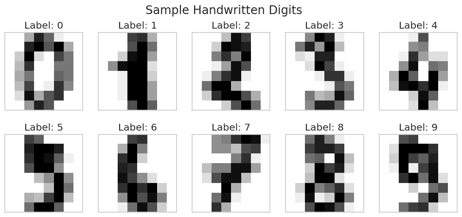

```python
print("--- Part 1: Dataset Loading and Inspection ---")

# 1. Load the Digits dataset
digits = load_digits()
X = digits.data
y = digits.target

print(f"Data shape (X): {X.shape}")
print(f"Target shape (y): {y.shape}")
print(f"Number of features (dimensions): {X.shape[1]}")
print(f"Number of unique classes (digits): {len(np.unique(y))}")

# 2. Visualize a few sample digits to understand the data
fig, axes = plt.subplots(2, 5, figsize=(12, 5), subplot_kw={'xticks':[], 'yticks':[]})
for i, ax in enumerate(axes.flat):
    ax.imshow(X[i].reshape(8, 8), cmap='binary')
    ax.set_title(f"Label: {y[i]}")
plt.suptitle("Sample Handwritten Digits")
plt.show()
```

### **Part 2: Principal Component Analysis (PCA) for Dimensionality Reduction**

**PCA** is a linear technique that transforms the data into a new coordinate system. The new axes, called **principal components**, are orthogonal and are ordered by the amount of variance they capture from the original data. The first principal component is the direction of highest variance, the second is the next highest (orthogonal to the first), and so on.

**Key Idea:** We can often describe the vast majority of the data's structure (variance) using just a few principal components, allowing us to discard the rest with minimal information loss.

**Important:** PCA is highly sensitive to the scale of the features, so we **must** standardize the data first.

**Principal Component Analysis (PCA)** is a linear transformation technique that reduces dimensionality while preserving as much variance (information) as possible.  
It identifies **principal components (PCs)** — new orthogonal axes — that capture the directions of **maximum variance** in the data.